# Features that affect the loan status of borrowers

## by Ebubechukwu Princewill Okoye

## Investigation Overview

In this investigation, i wanted to know what features in the prosper loan dataset affected the loan status of a borrower. The main features of focus were; income range, employment status, income verifiable, investors, loan original amount, and listing category.

I start by introducing the loan status feature. Then, using barplot, i check for the effect of avg. number of investors on loan status. Subsequently, using the heatmap and boxplot i presented the effects other chosen features have on loan status. Finally, i check for the interaction effect of income verifiable and average number of investors on loan status using a barplot.

## Dataset Overview

The dataset comprises of loan status and 80 other features of 113937 entries, generated from prosper loan company.

## Distribution of Loan Status

Plotting a barchart of the loan status observation in a decreasing order, it is seen that greater number of borrowers were under the current loan status.

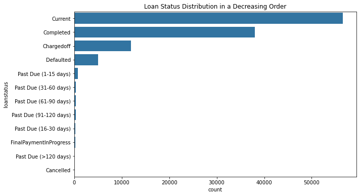

## Loan Status Vs Investors

A plot between loan status and average number of investors revealed that those patronised by low number of investors on the average were not granted loan.

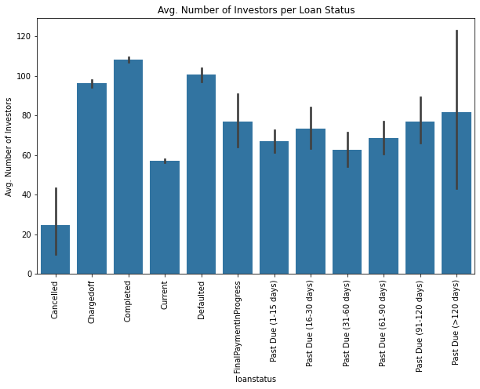

## Loan Status Vs Employment Status

A heatmap between the two features showed that most individuals Employed or working Full-time had a loan status of current and completed. It also showed that those that didn't provide their employment status at the time the data was pulled were not under the current loan status.

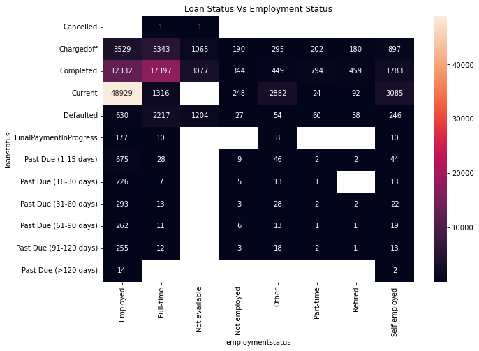

## Loan Status Vs Income Range

Most individuals found in the high income ranges also fall under current and completed loan status.

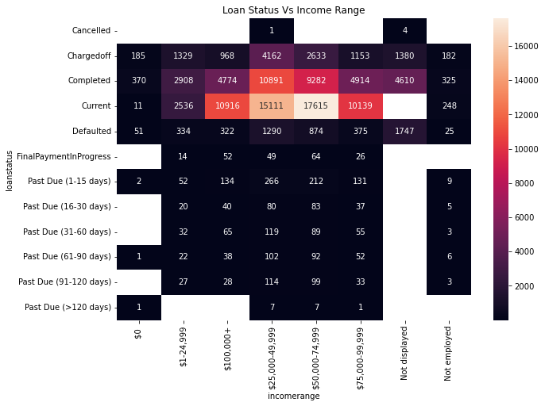

## Loan Status Vs Loan Original Amount

Those with current loan status applied for higher loan amounts unlike those that their loan was not approved(cancelled).

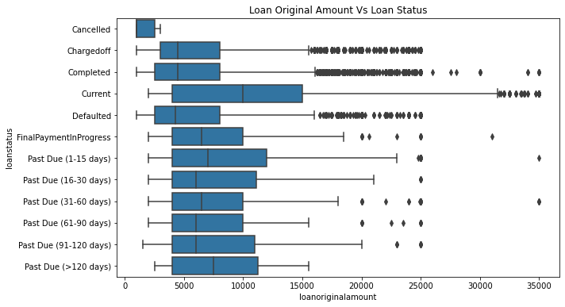

## Loan Status Vs Income Verifiable

Plotting a proportion barchart shows that the proportion of those with a verifiable income is higher than the proportion of those with none in the current and completed loan status.

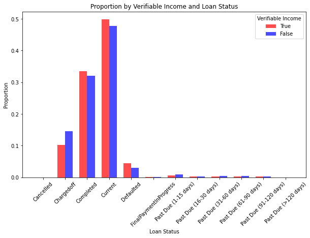

## Loan Status Vs Listing Category

The listing category feature depicts the category of the listing that the borrower selected when posting their listing.

The heatmap showed that very few loans were cancelled using the listing category as a basis. And out of the many persons on current loan status, very few(only 12) persons that didn't indicate a reason(not available) were granted loans. Also those with reasons such as for personal loan and student loan were not on current loan status.

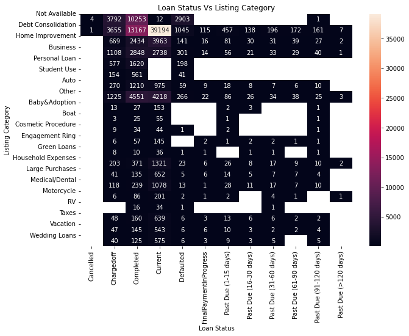

## Loan Status by Investors and Income Verifiable

The average number of investors for those with a verifiable income document is higher for most loan status. Most especially the completed loan status.

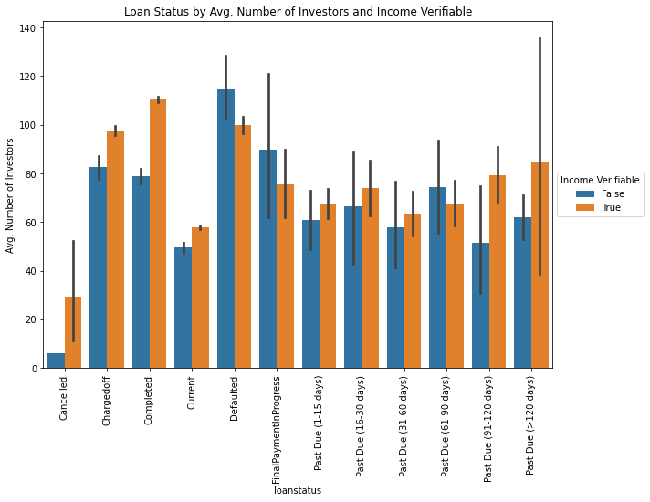